# Counting Majority-Black Districts

Six defensible answers, and what happens between packing and cracking

Democracy’s Data

Last updated September 13, 2026 at 10:53a EDT

American voting-rights law reaches for one remedy above all others: a district in which a minority group is a majority, and can elect the candidate it prefers. *Bartlett v. Strickland*, 556 U.S. 1, 19–20 (2009) made the 50 percent line the thing that decides a case.[^1] So how many majority-Black congressional districts does the country actually have? The question sounds like it has one answer.

The other half of it is what happens on the way to that line. A district can be **packed**, holding far more Black voters than a majority needs, so that the surplus elects nobody extra, or **cracked**, holding too few to elect anybody because the group was split across several districts. In between sits a band of districts that are 40 to 50 percent Black. Both questions are answered here from one Congress.

## The test

The population figures come from the Census Bureau’s **Citizen Voting Age Population Special Tabulation**, known as CVAP, built on the 2019–2023 American Community Survey — the Bureau’s continuous sample survey of households, and the only federal count that asks about citizenship — and published for each district of the 118th Congress (2023–2025).[^2] Its producer is the Bureau’s Redistricting Data Office, which exists because the Voting Rights Act needs it to. Thirteen race lines by four **population bases** — the bottom number a share is divided by: everybody, adults, citizens, and adult citizens — with a **margin of error** on every cell saying how far off the estimate could be, since it comes from a survey rather than a full count. No other file gives citizen voting-age population by district and race, and the 50 percent question cannot be asked without choosing a base.

Who each district elected is not in a federal file anywhere. No dataset records the race of a member of Congress: not the Clerk’s election statistics, not Voteview, not the Biographical Directory’s bulk data. The nearest institutional source is the U.S. House’s own Office of the Historian, which curates *Black Americans in Congress* and *Hispanic Americans in Congress*[^3] and publishes them as a search filter on a photo gallery. The 2020 presidential result for each district comes from The Downballot, an elections news site that recomputes presidential returns onto congressional district lines, here the 2022 lines the 118th Congress ran on.[^4]

Three files, and two joins. Districts and members meet on state and district number. The Historian’s lists meet the members on the **Bioguide ID**, the identifier Congress gives everyone who has served, which the Historian publishes nowhere except inside the filename of each member’s listing photograph. Every join carries the assumptions of both files plus one more about how they line up. That is the subject of Join Keys and Crosswalks, a crosswalk being a table that translates one set of identifiers into another.

One consequence belongs here rather than at the end. The Census file measures race by asking people to check boxes about themselves. The Historian’s list assigns race by editorial judgment, retrospectively, with no published inclusion rule. **The two sides of every table below use the same word to mean two different operations**, and nothing downstream repairs that.

## The data

Fifteen tables come out of this chapter’s build: the district-level data the model runs on, the published tables it is checked against, the model’s own output, and the race-labeling methods it compares along the way. Sizes are rows by columns, read off the files.

| Table | What it holds | Size |
| --- | --- | --- |
| `districts.csv` | One row per 118th Congress district: population, voting-age and citizen-voting-age composition on three bases with margins of error, Republican share, and who it elected. | 435 × 59 |
| `members.csv` | One row per person who served in the 118th House. | 445 × 11 |
| `bins.csv` | The 118th’s districts cut into Lublin’s Table 3A composition bins, with the denominators printed next to the percentages. | 60 × 6 |
| `lublin.csv` | Lublin’s Tables 3A, 3B, 4A and 4B as published, percentages and the counts behind them. | 60 × 8 |
| `lublin_t1.csv` | Lublin’s Table 1 as published. | 11 × 7 |
| `simulation.csv` | The Figure 1 model swept over Black-plus-Democratic share, Republican share, and the standard deviation the authors call arbitrary. | 3,318 × 4 |
| `sweetspot.csv` | Where the peak of that model sits, and how high, as the assumed standard deviation varies. | 28 × 7 |
| `fitted.csv` | The Figure 2 logit, refit on the 118th Congress. | 804 × 6 |
| `surface.csv` | Predicted electoral success over the full grid of minority share by Republican share. | 4,331 × 3 |
| `surname_check.csv` | One row per seated member: the surname file’s racial distribution for their name, beside the Historian’s own answer. | 435 × 15 |
| `surname_grade.csv` | The surname file graded against the Historian’s answers, at each confidence cutoff. | 10 × 7 |
| `surname_hyphen.csv` | Every two-part surname resolved both ways, and whether the 50% call changes depending on which half is taken. | 17 × 10 |
| `bisg_members.csv` | One row per member: the Historian’s answer beside the label from geography alone, from surname alone, and from BISG combining both. | 405 × 16 |
| `bisg_calibration.csv` | BISG’s error rate by district Black share – the table that decides whether the labels may be used downstream at all. | 5 × 9 |
| `bisg_downstream.csv` | The chapter’s logit model rerun on each set of race labels, to see whether the conclusion depends on which one was used. | 3 × 3 |

One more file is not data about districts or members – it is how this chapter checked its own work: `checks.csv`, the validation results printed at the end of the build.

One row is a congressional district, and there are 435 of them.

| District | Member | Party | Population | Black % of pop | Black % of adults | Black % of citizen adults | Trump % 2020 | Historian: Black |
| --- | --- | --- | --- | --- | --- | --- | --- | --- |
| SC-06 | James E. Clyburn | Democrat | 736925 | 48 | 46.5 | 47.9 | 33.2 | TRUE |

`key` names the district and `name`, `party` and `bioguide` name its member. Then `pop_total`, `vap_total` and `cvap_total` count everybody, the adults, and the citizen adults, each with `_black` and `_hisp` companions and a margin of error beside it. `rep_pct` is Trump’s 2020 share on those lines, and `black` and `hisp` are the Historian’s judgments.

| Quantity | Value |
| --- | --- |
| Congressional districts | 435 |
| People who served in the House | 445 |
| Seats that changed occupant | 10 |
| Districts electing a Black member | 59 |
| Districts electing a Latino member | 53 |
| Members on both Historian lists | 3 |
| Black members elected as Republicans | 4 |
| Latino members elected as Republicans | 16 |

Two cleaning decisions shaped that table. 445 people held these 435 seats, because **10 seats changed occupant mid-Congress**, and the member recorded here is the first to hold it. A rule keyed to opening day instead drops VA-04 entirely, because Donald McEachin died three weeks after winning it. And 3 members appear on **both** of the Historian’s lists, so the two categories are not exclusive.

The third decision is the one the count turns on. The stricter definition of the group is **Black alone**; the looser is **any-part Black**, alone or in combination, which is Voting Rights Act practice. The CVAP tabulation cannot express the looser one, because it breaks multiracial answers into named pairs plus a bucket called “Remainder of Two or More Race Responses” that it never decomposes. So the table carries **bounds**: Black alone at the bottom, and Black alone plus every combination plus the whole remainder bucket at the top.

**The federal tabulation built for the Voting Rights Act cannot express the Voting Rights Act’s own definition of the group it protects.**

> **Before you read on, write one number down.** You know that the 50% line decides a claim under the Voting Rights Act, and you are about to see the 118th Congress sorted by Black share. **How many majority-Black congressional districts are there?**

> Write a single integer. The question sounds like it has one.

## What it says about democracy

### Six answers to one question

Three population bases, crossed with two definitions of Black, give six defensible counts.

| Measure of “majority Black” | Districts over 50% |
| --- | --- |
| Total population, Black alone | 10 |
| Voting-age population, Black alone | 8 |
| Citizen voting-age population, Black alone | 11 |
| Total population, any-part Black | 14 |
| Voting-age population, any-part Black | 11 |
| Citizen voting-age population, any-part Black | 14 |

**Between 8 and 14.** Nothing else is in dispute: same Congress, same census file, six ways of reading it, and the count moves by 6, or 75% of the smallest answer. The disagreement is concentrated in the districts sitting on the line, which are the only ones where it could ever matter.

Take one district and count it six ways. PA-03, in Philadelphia, is the top row of Figure 1 below.

| Population base | Black alone | Any-part Black |
| --- | --- | --- |
| Total population | 52.4% | 55.0% |
| Voting-age population | 49.9% | 52.1% |
| Citizen voting-age population | 51.7% | 54.0% |

“Majority” here means strictly more than 50%, which is *Bartlett*’s reading; a district at exactly 50.0% would not count. On 5 of the six readings PA-03 is over the line, and on 1 it is under: Black alone, among adults, at 49.9%. Every count in the table above is this exercise run on all 435 districts, and the six answers differ because districts near the line, like this one, land on different sides of it depending on the reading.

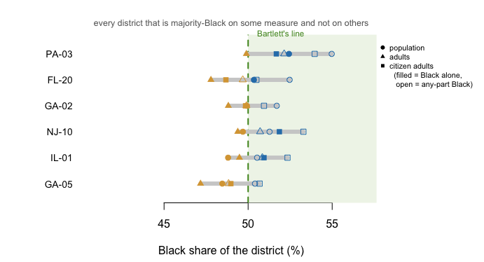

**Figure 1. Six answers per district.** The 6 districts that are over 50% Black on at least one of the six measures and under 50% on at least one other. One row per district fits this question because the question is whether a single district crosses a single line, and six marks on one row show the disagreement without arithmetic. Filled marks are Black alone and open marks any-part Black; the shape is the population base, and the dashed line is 50%.

Read the top row again. **PA-03 is over the line on the base most people quote, total population, and under it on the base the Supreme Court named, voting-age population.** Nobody moved, and the bottom number everything is divided by changed the answer.

The bounds are not uniformly narrow, either. Across all 435 districts the gap between Black-alone and any-part Black among adults has a median of 1.00 points. In Hawaii’s second district it is 14.8 points, because the unallocated multiracial bucket there is enormous. A national median hides the places where the definition does all the work.

### Between packing and cracking

A district does not have to be majority-Black to elect a Black member, and how far short it can fall is the question the literature argues about. David Lublin and colleagues sorted districts into bands by Black share and reported what share of each band elected a Black legislator.[^5] Here is their U.S. House row beside the same bands rebuilt on a Congress they could not have seen.

| Black share of total population | 2015, as published (Lublin Table 3A) | 118th Congress, rebuilt here |
| --- | --- | --- |
| 0-20% | 1.4% of 354 | 4.2% of 353 |
| 20-30% | 13.3% of 30 | 30.8% of 39 |
| 30-40% | 21.1% of 19 | 46.2% of 13 |
| 40-45% | 100.0% of 2 | 83.3% of 12 |
| 45-50% | 100.0% of 1 | 87.5% of 8 |
| 50-55% | 100.0% of 8 | 100.0% of 3 |
| 55-60% | 100.0% of 14 | 100.0% of 4 |
| 60-70% | 85.7% of 7 | 66.7% of 3 |
| 70-80% | – | – |
| 80-100% | – | – |

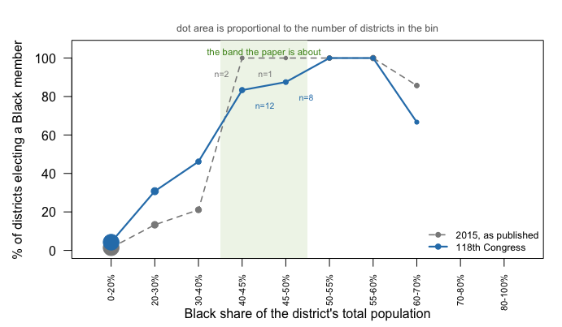

**Figure 2. The same bands, ten years apart.** Percentage of districts in each band that elected a Black member, in 2015 as published and in the 118th Congress as rebuilt here. Dot area is proportional to the number of districts each percentage was computed from, which is the point of the figure.

**The 40–50% band held 3 congressional districts in 2015 and holds 20 now**, of which 17 elected a Black member. In the published table the 40–45% cell reads 100.0% and is two districts, and the 45–50% cell reads 100.0% and is one. Both were printed to one decimal place, and both were correctly computed: the bottom number was simply small, and a percentage does not look small.

So the forecast came true and the 2015 table could not have shown it. A claim that rested on three districts now rests on 20, and it holds up. Being right is not the same as having shown it.

### The mechanism offered for it

The explanation on offer is about primaries. As white voters in the South left the Democratic primary, the Black share of the primary electorate rose, so a Black candidate could win the nomination well short of a district majority. That helps until Republicans grow numerous enough to take the general election. Between those two failures sits a **“sweet spot”** of Republican strength. The prediction is specific: hold the Black share of a district fixed, raise the Republican share, and the chance of a Black member should rise, peak and fall.

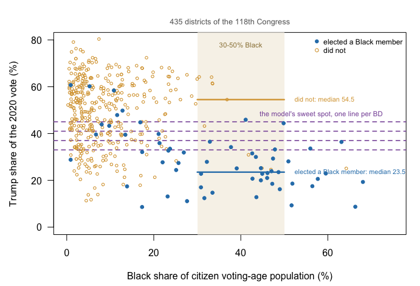

435 districts of the 118th Congress. Hover a point for the district and its member.

**Figure 3. Where Black members actually win.** Every district of the 118th Congress by its Black citizen voting-age share and its 2020 Trump share. The shaded band is the 30–50% range where the mechanism is supposed to operate, and the dashed lines are where the model puts the peak.

| Term | Estimate | Std. error | P |
| --- | --- | --- | --- |
| Black share of citizen voting-age population | +0.1100 | 0.0157 | <0.001 |
| Trump share | -0.0313 | 0.0694 | 0.652 |
| Trump share, squared | -0.0005 | 0.0009 | 0.601 |

**It is not there.** Fit Black electoral success against composition and against Republican share, with a squared term so the Republican effect is allowed to curve. Composition is overwhelming, and **neither Republican term can be told apart from zero**. The squared term, which is the whole curve claim, has p = 0.60 — a p-value being the chance of seeing a bend at least this large when there is none, so anything above the conventional 0.05 is read as no evidence — and the fitted curve has no maximum anywhere inside the range of the data.

The raw middles say the same thing backwards. Among the 34 districts between 30% and 50% Black, the ones that elected a Black member have a median Trump share of **23.5%** and the ones that did not have **54.5%**. Black candidates are winning these seats in the *least* Republican of them, not in the sweet spot.

There is a reason it does not show up: the model has no place for part of the chamber. **4 of the 59 Black members of the 118th House are Republicans**, and 16 of the 53 Latino members are too. The model assumes the only primary that matters is the Democratic one, which was reasonable when it was written. In this chamber 17.9% of Black and Latino members were elected as Republicans.

## What this brief cannot tell you

**Which of the six answers is right.** The any-part Black interval is a genuine interval rather than an estimate with error bars. This brief reports both ends and the districts that straddle the line, and it cannot say where inside the bounds the truth sits.

**Whether the sweet spot ever operated.** This is one Congress, seen once. That the mechanism is undetectable now is equally consistent with its having worked and stopped, with its having worked only in the South, and with its never having worked.

**Whether the Historian’s list is right.** It has no published inclusion rule, no appeal and no margin of error, and nothing here audits a single entry against anything. The 3 members on both lists show the categories overlap; they do not show the categories are otherwise correct.

**Anything about state legislatures.** The strongest evidence for the sweet spot sits in state house and senate rows with thousands of districts. The CVAP file ships those districts too, and this brief stops at Congress because no equivalent of the Historian’s list exists for the fifty states.

## What you should have learned

- “How many majority-Black districts are there” has six defensible answers from one file, running from 8 to 14, because three population bases cross two definitions of who counts as Black.
- The disagreement is concentrated: only 6 districts are over 50% on one measure and under it on another, and those are the only districts where the choice could decide a case.
- The federal tabulation built for the Voting Rights Act cannot express any-part Black, the definition the Act itself works with, so the honest answer is a pair of bounds.
- Districts well short of a majority now elect Black members routinely: the 40–50% band held 3 districts in 2015 and holds 20 today, 17 of which elected a Black member.
- The primary-electorate mechanism offered for that does not show up here. Republican share adds nothing once composition is held fixed, and 4 of 59 Black members were elected as Republicans, which the mechanism does not cover.

## Extensions

None of these is answered above, and every one can be answered from the tables the Sources section hands over.

- `bins.csv` counts districts and Black members elected in each band, by `base`. Compute the share elected per band for `total population` and again for `citizen voting-age population`. Does the band where districts start electing Black members move?
- `districts.csv` has `pop_black_low_pct` and `pop_black_high_pct` for every district. Sort by the gap between them. Which states hold the districts where the definition of Black matters most?
- `lublin.csv` carries `pct` and `n` for every published cell, including the `State House` and `State Senate` chambers. Find the cells whose `n` is under five. How much of the published argument sits on them?
- `fitted.csv` reports a `half`, the share at which the fitted curve crosses even odds, for each `model`. Compare the Black rows with the Latino rows. Why should the population base matter more for one group than the other?
- **Stretch.** The CVAP tabulation ships state legislative districts as well. Download one state’s file and count its majority-Black districts six ways, as above.
- **Stretch.** `members.csv` has `start` and `end` dates for everyone who served. Rebuild the counts using whoever held the seat longest rather than first, and see which districts change.

## Sources

**Data**

- U.S. Census Bureau, Redistricting Data Office. *Citizen Voting Age Population by Race and Ethnicity (CVAP) Special Tabulation, 2019–2023 American Community Survey*, congressional district file. https://www2.census.gov/programs-surveys/decennial/rdo/datasets/2023/2023-cvap/CVAP_2019-2023_ACS_csv_files.zip Thirteen race lines by four population bases, with a margin of error on every cell, for each of the 435 districts of the 118th Congress.
- Office of the Historian, U.S. House of Representatives. *Black Americans in Congress* and *Hispanic Americans in Congress*, as the People search filters `filter=1` and `filter=11`. https://history.house.gov/People/Search/ 201 and 170 members, all time. Each member’s Bioguide ID is taken from the listing, where it appears only in the filename of the member’s photograph; the sixteen members with no photograph are matched through their biography pages.
- `unitedstates/congress-legislators`, current and historical, a file of every member of Congress kept by volunteers on GitHub. https://unitedstates.github.io/congress-legislators/ (that address no longer resolved when last checked; the project itself is at https://github.com/unitedstates/congress-legislators). Who served, in which district, for which party, between which dates. It does not record race.
- The Downballot, presidential results by congressional district, 2020 on the 2022 lines. https://www.the-downballot.com/p/data The copy used is the one this book’s House competition chapter already holds.

**The data itself**

All fifteen tables are described in The data at the top of this brief. They are plain CSV, they open in a spreadsheet, and they are yours to take further: `districts.csv`, `members.csv`, `bins.csv`, `lublin.csv`, `lublin_t1.csv`, `simulation.csv`, `sweetspot.csv`, `fitted.csv`, `surface.csv`, `surname_check.csv`, `surname_grade.csv`, `surname_hyphen.csv`, `bisg_members.csv`, `bisg_calibration.csv`, `bisg_downstream.csv`.

**The paper**

David Lublin, Lisa Handley, Thomas L. Brunell and Bernard Grofman, “Minority Success in Non-Majority Minority Districts: Finding the ‘Sweet Spot’,” *Journal of Race, Ethnicity, and Politics* 5 (2020): 275–298, doi:10.1017/rep.2019.24. Tables 1, 3 and 4 are keyed in by hand from the published PDF, **including the case counts**.

**Cases**

- *Thornburg v. Gingles*, 478 U.S. 30 (1986), https://www.law.cornell.edu/supremecourt/text/478/30
- *Bartlett v. Strickland*, 556 U.S. 1 (2009), https://www.law.cornell.edu/supremecourt/text/07-689
- *Allen v. Milligan*, 599 U.S. 1 (2023), https://www.supremecourt.gov/opinions/22pdf/21-1086_1co6.pdf
- *Louisiana v. Callais*, 608 U.S. ___ (2026), https://www.supremecourt.gov/opinions/25pdf/24-109_new_jifl.pdf

Rebuild this data yourself, with an AI assistant

```
I want to rebuild a public dataset from its original sources, without
any starting files. Please do the following and show your work. One of
the three sources is not a data file at all, and that is the point.

THE FIRST SOURCE. U.S. Census Bureau, Citizen Voting Age Population
Special Tabulation from the 2019-2023 American Community Survey, made
by the Bureau's Redistricting Data Office because the Voting Rights
Act needs it. One zip, 54,962,776 bytes, at
https://www2.census.gov/programs-surveys/decennial/rdo/datasets/2023/2023-cvap/CVAP_2019-2023_ACS_csv_files.zip
No account or key is needed. Inside, the congressional-district file
has 5,720 rows: thirteen race lines for every district and delegate
seat, each line carrying total, adult, citizen, and citizen
voting-age counts with margins of error.

THE SECOND SOURCE. The unitedstates project's congress-legislators
files — who served, in which district, for which party:
https://unitedstates.github.io/congress-legislators/legislators-current.json
https://unitedstates.github.io/congress-legislators/legislators-historical.json
They carry a member's Twitter handle. They do not carry race.

THE THIRD SOURCE. No government data file records the race of a
member of Congress. The only machine-reachable form of it is the
House Historian's photo gallery, searched with two filters:
https://history.house.gov/People/Search?filter=1 for Black Americans
and https://history.house.gov/People/Search?filter=11 for Hispanic
Americans.

HOW TO DOWNLOAD THE THIRD ONE. The gallery prints photographs, not
identifiers — but each photograph's filename is the member's Bioguide
ID, the key that joins to every other congressional dataset. Read the
IDs out of the filenames; for the handful of members with no photo,
open the member's detail page and find the ID in the page body. The
site refuses requests without a browser user-agent, results come
twelve to a page, and the pager works only if you follow its own
links. This route is fragile and there is no sturdier one; verify
your totals against the result count the page itself prints.

WHAT TO BUILD.
1. One row per district of the 118th Congress: its citizen
   voting-age population, and the Black and Hispanic shares of it.
   Drop the delegate seats. The Black share needs care: the race
   lines cannot say who counts as Black in the any-part sense, so
   carry a low bound (Black alone) and a high one (Black in any
   combination, plus the unallocated multi-race remainder).
2. One row per person who served in the 118th House, with whether
   the Historian's gallery lists them as Black or Hispanic.
3. The join: how many districts elected a Black member, how many a
   Hispanic member, and the minority shares of the districts each
   group won in.

CHECK YOUR WORK. The copies this book used were downloaded in August
2026. If your rebuild matches them, you should find:
- 5,720 rows in the district file before any filtering
- 435 congressional districts once the delegate seats are dropped
- 201 Black and 170 Hispanic members of Congress, all time, on the
  gallery's own result counters
- 445 people served in the 118th House
The gallery grows with every Congress; larger all-time counts mean
new members were added, not that you made an error.
```

[^1]: *Bartlett v. Strickland*, 556 U.S. 1 (2009): https://www.law.cornell.edu/supremecourt/text/07-689.
[^2]: The Census Bureau’s CVAP page, where the tabulation and its documentation are published: https://www.census.gov/programs-surveys/decennial-census/about/voting-rights/cvap.html.
[^3]: Office of the Historian, U.S. House of Representatives: https://history.house.gov/Exhibitions-and-Publications/BAIC/Black-Americans-in-Congress/ and https://history.house.gov/Exhibitions-and-Publications/HAIC/Hispanic-Americans-in-Congress/.
[^4]: The Downballot’s data page: https://www.the-downballot.com/p/data.
[^5]: David Lublin, Lisa Handley, Thomas L. Brunell and Bernard Grofman, “Minority Success in Non-Majority Minority Districts: Finding the ‘Sweet Spot’,” *Journal of Race, Ethnicity, and Politics* 5, no. 2 (2020): 275–298, https://doi.org/10.1017/rep.2019.24.